# Presentation slides

## Linking to Data

[figure not shown]

## Linking to Data

- linked-data metadata models describe structure + composition of buildings
- this metadata provides **context** to better understand building data telemetry
- how do we associate data with the metadata model?
  - it's another "link"!

## Sources of Data and Telemetry

- some common ones:
  - historical telemetry (timeseries data)
  - building geometry, BIM
  - building energy models (BEM)
  - live telemetry (OPC-UA, BACnet, Modbus)

## Sources of Data and Telemetry

- link **to** these other sources:
  - preserve existing investments in models + tools
  - avoid unnecessary duplication
- often other DBs are better at those data anyway...

[figure not shown]

## Looking at an Example Model

```python
# load in the graph
import brickschema
g = brickschema.Graph()
g.load_file("ttl/Brick.ttl")
g.load_file("ttl/building-compiled.ttl")
print(f"Graph has {len(g)} triples")
```

```
Graph has 53476 triples
```

```python
# what kinds of entities are in the model?
df = sparql_to_df(g, """SELECT ?entity ?type WHERE {
  ?entity a ?type .
  FILTER(REGEX(STR(?entity), "^http://openmetrics.eu/openmetrics#"))
}""")
df.groupby('type').count().sort_values(by='entity', ascending=False).head(10)
```

| type | entity |
| --- | --- |
| https://w3id.org/bot#Element | 326 |
| https://brickschema.org/schema/Brick#TimeseriesReference | 323 |
| https://pi.pauwel.be/voc/buildingelement#Wall | 204 |
| https://pi.pauwel.be/voc/buildingelement#Door | 48 |
| https://brickschema.org/schema/Brick#Space | 36 |
| https://w3id.org/bot#Space | 36 |
| https://brickschema.org/schema/Brick#Zone | 19 |
| https://brickschema.org/schema/Brick#Terminal_Unit | 18 |
| https://brickschema.org/schema/Brick#Building_Electrical_Meter | 18 |
| https://brickschema.org/schema/Brick#Thermostat | 18 |

```python
# what kinds of data sources are in the model?
df = sparql_to_df(g, """SELECT ?entity ?type WHERE {
  ?entity rdf:type/rdfs:subClassOf* brick:Point .
  ?entity a ?type .
  FILTER(REGEX(STR(?entity), "^http://openmetrics.eu/openmetrics#"))
}""")
df.groupby('type').count().sort_values(by='entity', ascending=False).head(10)
```

| type | entity |
| --- | --- |
| https://brickschema.org/schema/Brick#Active_Power_Sensor | 17 |
| https://brickschema.org/schema/Brick#Delay_Parameter | 17 |
| https://brickschema.org/schema/Brick#Max_Temperature_Setpoint_Limit | 17 |
| https://brickschema.org/schema/Brick#Min_Temperature_Setpoint_Limit | 17 |
| https://brickschema.org/schema/Brick#Mode_Command | 17 |
| https://brickschema.org/schema/Brick#Occupancy_Sensor | 17 |
| https://brickschema.org/schema/Brick#On_Off_Command | 17 |
| https://brickschema.org/schema/Brick#Speed_Setpoint | 17 |
| https://brickschema.org/schema/Brick#Zone_Air_Temperature_Sensor | 17 |
| https://brickschema.org/schema/Brick#Zone_Air_Temperature_Setpoint | 17 |

Let's zoom into one of the "spaces" and see what is modeled there. Bold outlined nodes are other "entities" in the model; color-filled nodes are "classes" or "types". Edges represent properties and relationships

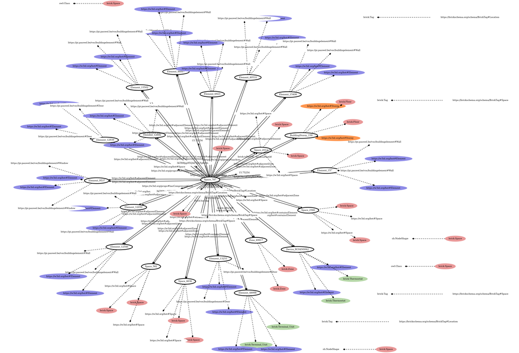

```python
space_graph = get_local_graph(g, URIRef("http://openmetrics.eu/openmetrics#Space_787"))
display.display_png(viz(space_graph))
```

Alternative textual representation:

```python
print(space_graph.serialize(format='ttl')[:1900])
```

```
@prefix brick: <https://brickschema.org/schema/Brick#> .
@prefix ns1: <https://w3id.org/bot#> .
@prefix ns2: <https://w3id.org/props#> .
@prefix owl: <http://www.w3.org/2002/07/owl#> .
@prefix rdfs: <http://www.w3.org/2000/01/rdf-schema#> .
@prefix sh: <http://www.w3.org/ns/shacl#> .
@prefix xsd: <http://www.w3.org/2001/XMLSchema#> .

<http://openmetrics.eu/openmetrics#Space_787> a brick:Space,
        ns1:Space ;
    rdfs:label "I2" ;
    brick:hasTag <https://brickschema.org/schema/BrickTag#Location>,
        <https://brickschema.org/schema/BrickTag#Space> ;
    brick:isPartOf <http://openmetrics.eu/openmetrics#BuildingStorey_159>,
        <http://openmetrics.eu/openmetrics#Zone_49917> ;
    ns1:adjacentElement <http://openmetrics.eu/openmetrics#Element_12450>,
        <http://openmetrics.eu/openmetrics#Element_12546>,
        <http://openmetrics.eu/openmetrics#Element_12642>,
        <http://openmetrics.eu/openmetrics#Element_12939>,
        <http://openmetrics.eu/openmetrics#Element_13255>,
        <http://openmetrics.eu/openmetrics#Element_15406>,
        <http://openmetrics.eu/openmetrics#Element_15502>,
        <http://openmetrics.eu/openmetrics#Element_15598>,
        <http://openmetrics.eu/openmetrics#Element_40510>,
        <http://openmetrics.eu/openmetrics#Element_44007>,
        <http://openmetrics.eu/openmetrics#Element_6923>,
        <http://openmetrics.eu/openmetrics#Element_9537> ;
    ns1:adjacentZone <http://openmetrics.eu/openmetrics#Space_2013>,
        <http://openmetrics.eu/openmetrics#Space_2566>,
        <http://openmetrics.eu/openmetrics#Space_4636>,
        <http://openmetrics.eu/openmetrics#Space_582> ;
    ns1:containsElement <http://openmetrics.eu/openmetrics#Device_RC04N0062>,
        <http://openmetrics.eu/openmetrics#Element_48998> ;
    ns2:hasArea 1.575254e+01 ;
    ns2:hasCompressedGuid "3kT8I8pp95QAZ7pLPg6v4h" .

<http://openmetric
```

[figure not shown]

Use queries against the *model* to find interesting/relevant data sources, then go fetch the data and analyze!

## Find Sensors in Spaces

Write quick SPARQL query to find sensors which measure locations

```python
df = sparql_to_df(g, """SELECT ?sensor ?data_id ?location WHERE {
   ?sensor rdf:type/rdfs:subClassOf* brick:Sensor .
   ?sensor ref:hasExternalReference/ref:hasTimeseriesId ?data_id .
   ?sensor brick:isPointOf ?location .
   ?location rdf:type/rdfs:subClassOf* brick:Location
}""")
df.head()
```

|  | sensor | data_id | location |
| --- | --- | --- | --- |
| 0 | http://openmetrics.eu/openmetrics#RC04N0061_Oc... | TUC.245.77.R4 | http://openmetrics.eu/openmetrics#Space_582 |
| 1 | http://openmetrics.eu/openmetrics#RC04N0061_Power | TUC.245.77.R2 | http://openmetrics.eu/openmetrics#Space_582 |
| 2 | http://openmetrics.eu/openmetrics#RC04N0061_Te... | TUC.245.77.R0 | http://openmetrics.eu/openmetrics#Space_582 |
| 3 | http://openmetrics.eu/openmetrics#RC04N0062_Oc... | TUC.245.77.R104 | http://openmetrics.eu/openmetrics#Space_787 |
| 4 | http://openmetrics.eu/openmetrics#RC04N0062_Power | TUC.245.77.R102 | http://openmetrics.eu/openmetrics#Space_787 |

Restricting our search to just temperature sensors...

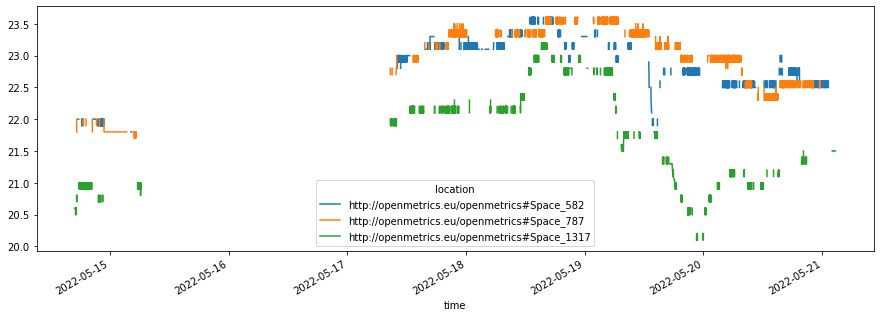

```python
df = sparql_to_df(g, """SELECT ?sensor ?data_id ?location WHERE {
   ?sensor rdf:type/rdfs:subClassOf* brick:Temperature_Sensor .
   ?sensor ref:hasExternalReference/ref:hasTimeseriesId ?data_id .
   ?sensor brick:isPointOf ?location .
   ?location rdf:type/rdfs:subClassOf* brick:Location
}""")
df = get_data(df.data_id[:3], df.location[:3])
_ = df.plot(figsize=(15,5))
```

Get sensors and setpoints for the same space

```python
df = sparql_to_df(g, """SELECT ?sensor_id ?sp_id ?location WHERE {
   ?sensor rdf:type/rdfs:subClassOf* brick:Temperature_Sensor .
   ?sensor ref:hasExternalReference/ref:hasTimeseriesId ?sensor_id .
   ?sensor brick:isPointOf ?location .

   ?sp rdf:type/rdfs:subClassOf* brick:Temperature_Setpoint .
   ?sp ref:hasExternalReference/ref:hasTimeseriesId ?sp_id .
   ?sp brick:isPointOf ?location .
   ?location rdf:type/rdfs:subClassOf* brick:Location
}""")
df.head()
```

|  | sensor_id | sp_id | location |
| --- | --- | --- | --- |
| 0 | TUC.245.77.R80 | TUC.245.77.R88 | http://openmetrics.eu/openmetrics#Space_1317 |
| 1 | TUC.245.77.R440 | TUC.245.77.R448 | http://openmetrics.eu/openmetrics#Space_1854 |
| 2 | TUC.245.77.R20 | TUC.245.77.R28 | http://openmetrics.eu/openmetrics#Space_338 |
| 3 | TUC.245.77.R380 | TUC.245.77.R388 | http://openmetrics.eu/openmetrics#Space_3457 |
| 4 | TUC.245.77.R360 | TUC.245.77.R368 | http://openmetrics.eu/openmetrics#Space_3641 |

Plot sensor vs setpoint

[figure not shown]

```python
# grab sensor+setpoint name
(sensor, sp, _) = df[df.location == 'http://openmetrics.eu/openmetrics#Space_3641'].values[0]
# get the data
d = get_data([sensor, sp], ['sensor', 'setpoint'])['2022-05-17':]
# plot it!
ax = d.plot(figsize=(15,5)) ; _ = ax.set_title(space_name)
```

## Setpoint Deviation Analysis

Produce the distribution of deviation from setpoint for all spaces in the building

```python
def avg_deviation(space_name):
    # get names of data points for the space
    (sensor, sp, _) = df[df.location == space_name].values[0]
    # get the actual data
    d = get_data([sensor, sp], ['sensor', 'setpoint'])
    # do a little cleaning
    d.dropna(inplace=True)
    # compute average absolute deviation
    return (d['setpoint'] - d['sensor']).abs().mean()
```

```python
# now run for all spaces in our building
all_spaces = df.location.unique()
deviations = pd.DataFrame({'space': all_spaces,
                           'deviation': [avg_deviation(space) for space in all_spaces]})
deviations.sort_values(by='deviation', ascending=False).head(10)
```

|  | space | deviation |
| --- | --- | --- |
| 15 | http://openmetrics.eu/openmetrics#Space_3110 | 5.800000 |
| 1 | http://openmetrics.eu/openmetrics#Space_1854 | 5.005882 |
| 8 | http://openmetrics.eu/openmetrics#Space_969 | 4.592857 |
| 9 | http://openmetrics.eu/openmetrics#Space_1147 | 4.491667 |
| 5 | http://openmetrics.eu/openmetrics#Space_3819 | 4.416667 |
| 16 | http://openmetrics.eu/openmetrics#Space_2934 | 3.981818 |
| 6 | http://openmetrics.eu/openmetrics#Space_582 | 3.655556 |
| 10 | http://openmetrics.eu/openmetrics#Space_1680 | 3.600000 |
| 4 | http://openmetrics.eu/openmetrics#Space_3641 | 3.341379 |
| 7 | http://openmetrics.eu/openmetrics#Space_787 | 3.188889 |

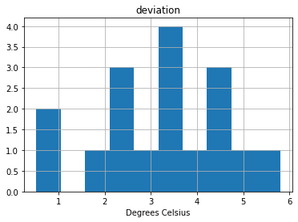

```python
ax = deviations.hist()
_ = ax[0][0].set_xlabel('Degrees Celsius')
```